# Project: Investigate The Movie Database (TMDb)

- Introduction
- Data Wrangling
- Exploratory Data Analysis
- Conclusions

## Introduction:

This dataset comes from IMDB and contains information about 10,000 movies,short films and tv series collected from The Movie Database (TMDb), including user ratings, revenue, runtime and the budget. In this project, i'll be answering the following questions about the movies:

- what the genre type of the movie that have the most popularity ,how much budget did it cost,revenue and in which year releaced ?
- what was the worst movie or tv series,which year released and how much budget did it cost ?
- did the number of released movies increased per year and in which year released the most numbers of movies?
- what type of the relationship between budget and revenue ?
- is there any relationship between budget and runtime ?
- is there any relationship between revenue and runtime ?
- what is the relationship between the revenue and the release year ?
- what type of the relationship between popularity and revenue ?

```python
# import the packages that we will use
import pandas as pd
import numpy as np
import matplotlib.pyplot as plt
import seaborn as sns
sns.set_style('darkgrid')
%matplotlib inline
```

## Data Wrangling

> Explore General Properties of the Dataset

### General Properties

```python
# Load the data and print out a few lines. Perform operations to inspect data
movies = pd.read_csv('tmdb-movies.csv')
pd.options.display.max_columns = 25
movies.head(2)
```

|  | id | imdb_id | popularity | budget | revenue | original_title | cast | homepage | director | tagline | keywords | overview | runtime | genres | production_companies | release_date | vote_count | vote_average | release_year | budget_adj | revenue_adj |
| --- | --- | --- | --- | --- | --- | --- | --- | --- | --- | --- | --- | --- | --- | --- | --- | --- | --- | --- | --- | --- | --- |
| 0 | 135397 | tt0369610 | 32.985763 | 150000000 | 1513528810 | Jurassic World | Chris Pratt\|Bryce Dallas Howard\|Irrfan Khan\|Vi... | http://www.jurassicworld.com/ | Colin Trevorrow | The park is open. | monster\|dna\|tyrannosaurus rex\|velociraptor\|island | Twenty-two years after the events of Jurassic ... | 124 | Action\|Adventure\|Science Fiction\|Thriller | Universal Studios\|Amblin Entertainment\|Legenda... | 6/9/15 | 5562 | 6.5 | 2015 | 1.379999e+08 | 1.392446e+09 |
| 1 | 76341 | tt1392190 | 28.419936 | 150000000 | 378436354 | Mad Max: Fury Road | Tom Hardy\|Charlize Theron\|Hugh Keays-Byrne\|Nic... | http://www.madmaxmovie.com/ | George Miller | What a Lovely Day. | future\|chase\|post-apocalyptic\|dystopia\|australia | An apocalyptic story set in the furthest reach... | 120 | Action\|Adventure\|Science Fiction\|Thriller | Village Roadshow Pictures\|Kennedy Miller Produ... | 5/13/15 | 6185 | 7.1 | 2015 | 1.379999e+08 | 3.481613e+08 |

```python
#  the numbers of movies,short Films and series(rows) and their features(columns)
movies.shape
```

```
(10866, 21)
```

```python
# the name of the columns
movies.columns
```

```
Index(['id', 'imdb_id', 'popularity', 'budget', 'revenue', 'original_title',
       'cast', 'homepage', 'director', 'tagline', 'keywords', 'overview',
       'runtime', 'genres', 'production_companies', 'release_date',
       'vote_count', 'vote_average', 'release_year', 'budget_adj',
       'revenue_adj'],
      dtype='object')
```

```python
# Explore the dataset
movies.describe()
```

|  | id | popularity | budget | revenue | runtime | vote_count | vote_average | release_year | budget_adj | revenue_adj |
| --- | --- | --- | --- | --- | --- | --- | --- | --- | --- | --- |
| count | 10866.000000 | 10866.000000 | 1.086600e+04 | 1.086600e+04 | 10866.000000 | 10866.000000 | 10866.000000 | 10866.000000 | 1.086600e+04 | 1.086600e+04 |
| mean | 66064.177434 | 0.646441 | 1.462570e+07 | 3.982332e+07 | 102.070863 | 217.389748 | 5.974922 | 2001.322658 | 1.755104e+07 | 5.136436e+07 |
| std | 92130.136561 | 1.000185 | 3.091321e+07 | 1.170035e+08 | 31.381405 | 575.619058 | 0.935142 | 12.812941 | 3.430616e+07 | 1.446325e+08 |
| min | 5.000000 | 0.000065 | 0.000000e+00 | 0.000000e+00 | 0.000000 | 10.000000 | 1.500000 | 1960.000000 | 0.000000e+00 | 0.000000e+00 |
| 25% | 10596.250000 | 0.207583 | 0.000000e+00 | 0.000000e+00 | 90.000000 | 17.000000 | 5.400000 | 1995.000000 | 0.000000e+00 | 0.000000e+00 |
| 50% | 20669.000000 | 0.383856 | 0.000000e+00 | 0.000000e+00 | 99.000000 | 38.000000 | 6.000000 | 2006.000000 | 0.000000e+00 | 0.000000e+00 |
| 75% | 75610.000000 | 0.713817 | 1.500000e+07 | 2.400000e+07 | 111.000000 | 145.750000 | 6.600000 | 2011.000000 | 2.085325e+07 | 3.369710e+07 |
| max | 417859.000000 | 32.985763 | 4.250000e+08 | 2.781506e+09 | 900.000000 | 9767.000000 | 9.200000 | 2015.000000 | 4.250000e+08 | 2.827124e+09 |

```python
# check the data type of each column
movies.dtypes
```

```
id                        int64
imdb_id                  object
popularity              float64
budget                    int64
revenue                   int64
original_title           object
cast                     object
homepage                 object
director                 object
tagline                  object
keywords                 object
overview                 object
runtime                   int64
genres                   object
production_companies     object
release_date             object
vote_count                int64
vote_average            float64
release_year              int64
budget_adj              float64
revenue_adj             float64
dtype: object
```

```python
# convert the data type of the release date from object to datetime
movies['release_date'] = pd.to_datetime(movies['release_date'])
```

```python
# check if we have zero values in the budget and how many
len(movies.query('budget == 0'))
```

```
5696
```

```python
#check the zero values in revenue
len(movies.query('revenue == 0'))
```

```
6016
```

```python
# check the runtime columns if we have zero values
len(movies.query('runtime == 0'))
```

```
31
```

```python
# replace the zeros with NaN then we check it
# sum the number of missing values in each column
movies['budget'] = movies['budget'].replace(0,np.NaN)
movies['revenue'] = movies['revenue'].replace(0,np.NaN)
movies['runtime'] = movies['runtime'].replace(0,np.NaN)
movies.isnull().sum()
```

```
id                         0
imdb_id                   10
popularity                 0
budget                  5696
revenue                 6016
original_title             0
cast                      76
homepage                7930
director                  44
tagline                 2824
keywords                1493
overview                   4
runtime                   31
genres                    23
production_companies    1030
release_date               0
vote_count                 0
vote_average               0
release_year               0
budget_adj                 0
revenue_adj                0
dtype: int64
```

```python
# make a copy of the Dataset before start cleaning
movies1 = movies.copy()
```

```python
# check if we have duplicated rows and how many
movies1.duplicated().sum()
```

```
1
```

### Data Cleaning (replace the missing values with suited values and drop the dupicated column)

```python
# remove the duplicated row
movies1.drop_duplicates(inplace = True)
```

```python
# remove the rows that doesn't have runtime
# since the runtime doesn't exist then there is no movie too
movies1 = movies1.dropna(subset = ['runtime'],axis = 0)
# remove the rows that doesn't have cast too
movies1 = movies1.dropna(subset = ['cast'],axis = 0)
# remove the rows that doesn't have genre
movies1 = movies1.dropna(subset = ['genres'],axis = 0)
```

```python
# check the missing values in each column and sum them
movies1.isnull().sum()
```

```
id                         0
imdb_id                    8
popularity                 0
budget                  5583
revenue                 5893
original_title             0
cast                       0
homepage                7840
director                  34
tagline                 2732
keywords                1430
overview                   2
runtime                    0
genres                     0
production_companies     959
release_date               0
vote_count                 0
vote_average               0
release_year               0
budget_adj                 0
revenue_adj                0
dtype: int64
```

```python
#  replace the missing values in the budget column with the mean
movies1['budget'].fillna(round(movies1['budget'].mean()),inplace = True)
```

```python
#  replace the missing values in the revenue column with the mean
movies1['revenue'].fillna(round(movies1['revenue'].mean()),inplace = True)
```

```python
# use fillna to replace the missing values(NaN)
movies1['director'].fillna(movies1.production_companies,inplace = True)
movies1['tagline'].fillna(movies1.original_title,inplace = True)
movies1['keywords'].fillna(movies1.original_title,inplace = True)
movies1['production_companies'].fillna('private',inplace = True)
movies1['homepage'].fillna('not available on internet',inplace = True)
```

```python
# check if we still have duplicated rows
movies1.duplicated().sum()
```

```
0
```

```python
# check the data if we still have missing values
movies1.isnull().sum()
```

```
id                       0
imdb_id                  8
popularity               0
budget                   0
revenue                  0
original_title           0
cast                     0
homepage                 0
director                15
tagline                  0
keywords                 0
overview                 2
runtime                  0
genres                   0
production_companies     0
release_date             0
vote_count               0
vote_average             0
release_year             0
budget_adj               0
revenue_adj              0
dtype: int64
```

```python
# replace the missing values
movies1['imdb_id'].fillna(movies1.id,inplace = True)
movies1['director'].fillna(movies1.production_companies,inplace = True)
movies1['overview'].fillna('not available',inplace = True)
```

```python
# make a copy of the cleaned Dataset
cleaned_movies = movies1.copy()
```

```python
# check the genres column(pipe)
cleaned_movies.genres.head(2)
```

```
0    Action|Adventure|Science Fiction|Thriller
1    Action|Adventure|Science Fiction|Thriller
Name: genres, dtype: object
```

```python
# check the keywords column(pipe)
cleaned_movies.keywords.head(2)
```

```
0    monster|dna|tyrannosaurus rex|velociraptor|island
1     future|chase|post-apocalyptic|dystopia|australia
Name: keywords, dtype: object
```

```python
# check the director column(pipe)
cleaned_movies.director.head(12)
```

```
0                    Colin Trevorrow
1                      George Miller
2                   Robert Schwentke
3                        J.J. Abrams
4                          James Wan
5     Alejandro GonzÃ¡lez IÃ±Ã¡rritu
6                        Alan Taylor
7                       Ridley Scott
8           Kyle Balda|Pierre Coffin
9                        Pete Docter
10                        Sam Mendes
11    Lana Wachowski|Lilly Wachowski
Name: director, dtype: object
```

```python
# check the cast column(pipe)
cleaned_movies.cast.head(2)
```

```
0    Chris Pratt|Bryce Dallas Howard|Irrfan Khan|Vi...
1    Tom Hardy|Charlize Theron|Hugh Keays-Byrne|Nic...
Name: cast, dtype: object
```

```python
# this is a function that Udacity reviewers asked for in my first review and I will use it at the end
# function will take the column values,seperate them and count them
def split_count(column_name):
# will take a column, and separate the string by '|'
    column_values = cleaned_movies[column_name].str.cat(sep = '|')

# giving pandas series and storing the values separately
    column_values = pd.Series(column_values.split('|'))

# this wil give us value in descending order
    count = column_values.value_counts(ascending = False)

    return count
```

```python
# good options if we need to see the whole rows
# pd.options.display.max_rows=10866
#cleaned_movies.genres
```

```python
# drop unnecessary columns to our questions
cleaned_movies1 = cleaned_movies.copy()
cleaned_movies1.drop(['id','imdb_id','homepage','overview'
                      ,'production_companies','budget_adj','revenue_adj'],axis = 1,
                     inplace = True)
```

```python
# see the columns that left and how many
for i,e in enumerate(cleaned_movies1.columns):
    print(i,e)
cleaned_movies1.shape[1]
```

```
0 popularity
1 budget
2 revenue
3 original_title
4 cast
5 director
6 tagline
7 keywords
8 runtime
9 genres
10 release_date
11 vote_count
12 vote_average
13 release_year
```

```
14
```

## Exploratory Data Analysis

```python
# adjust the column names
cleaned_movies1.rename(index = str,columns ={'budget':'budget($)',
                                             'revenue':'revenue($)',
                                             'runtime':'runtime(min)'},inplace = True)
```

```python
# have a quick look and explore our dataset
cleaned_movies1.describe()
```

|  | popularity | budget($) | revenue($) | runtime(min) | vote_count | vote_average | release_year |
| --- | --- | --- | --- | --- | --- | --- | --- |
| count | 10737.000000 | 1.073700e+04 | 1.073700e+04 | 10737.000000 | 10737.000000 | 10737.000000 | 10737.000000 |
| mean | 0.652212 | 3.082252e+07 | 8.932364e+07 | 102.699544 | 219.690603 | 5.968855 | 2001.257334 |
| std | 1.004516 | 2.697103e+07 | 1.089007e+08 | 30.470645 | 578.676174 | 0.931291 | 12.822022 |
| min | 0.000065 | 1.000000e+00 | 2.000000e+00 | 3.000000 | 10.000000 | 1.500000 | 1960.000000 |
| 25% | 0.210680 | 1.900000e+07 | 4.026302e+07 | 90.000000 | 17.000000 | 5.400000 | 1995.000000 |
| 50% | 0.386979 | 3.082252e+07 | 8.932364e+07 | 99.000000 | 39.000000 | 6.000000 | 2006.000000 |
| 75% | 0.720175 | 3.082252e+07 | 8.932364e+07 | 112.000000 | 148.000000 | 6.600000 | 2011.000000 |
| max | 32.985763 | 4.250000e+08 | 2.781506e+09 | 900.000000 | 9767.000000 | 9.200000 | 2015.000000 |

### Research Question 1

- what the genre type of the movie that have the most popularity ,how much budget did it cost,revenue and in which year releaced ?

```python
# the answer for our first question
pd.DataFrame(cleaned_movies1.loc[cleaned_movies1.popularity.idxmax()])
```

|  | 0 |
| --- | --- |
| popularity | 32.9858 |
| budget($) | 1.5e+08 |
| revenue($) | 1.51353e+09 |
| original_title | Jurassic World |
| cast | Chris Pratt\|Bryce Dallas Howard\|Irrfan Khan\|Vi... |
| director | Colin Trevorrow |
| tagline | The park is open. |
| keywords | monster\|dna\|tyrannosaurus rex\|velociraptor\|island |
| runtime(min) | 124 |
| genres | Action\|Adventure\|Science Fiction\|Thriller |
| release_date | 2015-06-09 00:00:00 |
| vote_count | 5562 |
| vote_average | 6.5 |
| release_year | 2015 |

### Research Question 2

- what was the worst movie or tv series,which year released and how much budget did it cost ?

```python
# the answer for our second question
pd.DataFrame(cleaned_movies1.loc[cleaned_movies1.popularity.idxmin()])
```

|  | 6181 |
| --- | --- |
| popularity | 6.5e-05 |
| budget($) | 3.08225e+07 |
| revenue($) | 8.93236e+07 |
| original_title | North and South, Book I |
| cast | Patrick Swayze\|Philip Casnoff\|Kirstie Alley\|Ge... |
| director | private |
| tagline | North and South, Book I |
| keywords | North and South, Book I |
| runtime(min) | 561 |
| genres | Drama\|History\|Western |
| release_date | 1985-11-03 00:00:00 |
| vote_count | 17 |
| vote_average | 6 |
| release_year | 1985 |

```python
# make a copy of the data
genres_movies = cleaned_movies1.copy()
genres_movies.head(2)
```

|  | popularity | budget($) | revenue($) | original_title | cast | director | tagline | keywords | runtime(min) | genres | release_date | vote_count | vote_average | release_year |
| --- | --- | --- | --- | --- | --- | --- | --- | --- | --- | --- | --- | --- | --- | --- |
| 0 | 32.985763 | 150000000.0 | 1.513529e+09 | Jurassic World | Chris Pratt\|Bryce Dallas Howard\|Irrfan Khan\|Vi... | Colin Trevorrow | The park is open. | monster\|dna\|tyrannosaurus rex\|velociraptor\|island | 124.0 | Action\|Adventure\|Science Fiction\|Thriller | 2015-06-09 | 5562 | 6.5 | 2015 |
| 1 | 28.419936 | 150000000.0 | 3.784364e+08 | Mad Max: Fury Road | Tom Hardy\|Charlize Theron\|Hugh Keays-Byrne\|Nic... | George Miller | What a Lovely Day. | future\|chase\|post-apocalyptic\|dystopia\|australia | 120.0 | Action\|Adventure\|Science Fiction\|Thriller | 2015-05-13 | 6185 | 7.1 | 2015 |

### Research Question 3

- did the number of released movies increased per year and in which year released the most numbers of movies?

```python
# make new dataframe contain the years and
# the numbers of the released movies every year
year_movies =pd.DataFrame(cleaned_movies1.release_year.value_counts())
year_movies = year_movies.astype('int64')
```

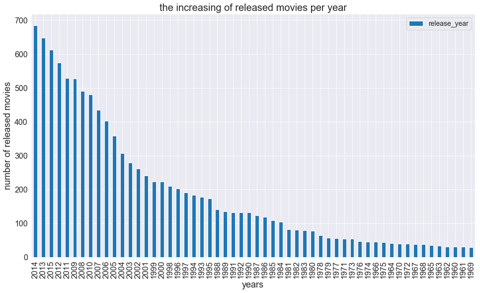

```python
# plotting the released movies every year
year_movies.plot(kind = 'bar',figsize = (16,9),fontsize= 16)
plt.title('the increasing of released movies per year',fontsize = 20)
plt.xlabel('years',fontsize = 18)
plt.ylabel('number of released movies',fontsize = 18)
plt.legend(fontsize = 14);
```

```python
# check the maximum number of released movies,in which year
year_movies[year_movies == year_movies.max()].head(1)
```

|  | release_year |
| --- | --- |
| 2014 | 684.0 |

```python
# check the minimum number of released movies,in which year
year_movies.idxmin(),year_movies.min()
```

```
(release_year    1969
 dtype: int64, release_year    30
 dtype: int64)
```

### Research Question 4

- what type of the relationship between budget and revenue ?

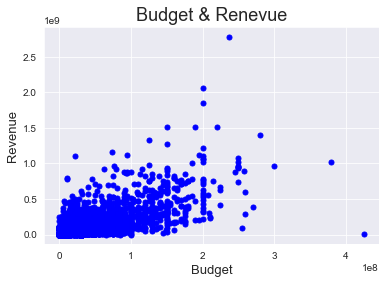

```python
# plotting budget_revenue
budget_revenue = pd.DataFrame(cleaned_movies[['budget','revenue']])
plt.scatter(x = budget_revenue.budget, y = budget_revenue.revenue,
            color = 'blue',s = (5*5))
plt.title('Budget & Renevue',fontsize = 18)
plt.xlabel('Budget',fontsize = 13)
plt.ylabel('Revenue',fontsize = 13);
```

### Research Question 5

- is there any relationship between budget and runtime ?

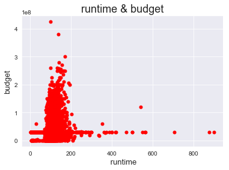

```python
# plotting runtime and budget
plt.scatter(cleaned_movies['runtime'], cleaned_movies['budget'], s= (5*5),
            color='red')
plt.title('runtime & budget',fontsize = 18)
plt.xlabel(' runtime',fontsize = 13)
plt.ylabel('budget',fontsize = 13);
```

**as we could see there is no relationship between the budget and the runtime**

### Research Question 6

- is there any relationship between revenue and runtime ?

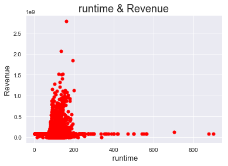

```python
# plotting runtime and revenue
plt.scatter(cleaned_movies['runtime'], cleaned_movies['revenue'], s= (5*5),
            color='red')
plt.title('runtime & Revenue',fontsize = 18)
plt.xlabel(' runtime',fontsize = 13)
plt.ylabel('Revenue',fontsize = 13);
```

**as we can see there is no relationship between the revenue and the runtime**

### Research Question 7

- what is the relationship between the revenue and the release year ?

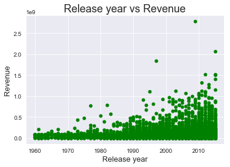

```python
# plotting Release year vs Revenue

plt.scatter(cleaned_movies['release_year'], cleaned_movies['revenue'], s= (5*5),
            color='g')
plt.title('Release year vs Revenue',fontsize = 18)
plt.xlabel('Release year',fontsize = 13)
plt.ylabel('Revenue',fontsize = 13);
```

**we could see it's classification and positive relationship**

### Research Question 8

- what type of the relationship between popularity and revenue ?

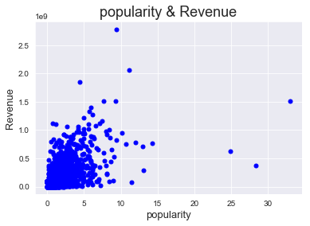

```python
# plotting popularity & Revenue
plt.scatter(cleaned_movies['popularity'], cleaned_movies['revenue'], s= (5*5),
            color='b')
plt.title('popularity & Revenue',fontsize = 18)
plt.xlabel('popularity',fontsize = 13)
plt.ylabel('Revenue',fontsize = 13);
```

**we could see it's a positive relationship**

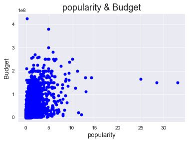

```python
# plotting popularity & Budget
plt.scatter(cleaned_movies['popularity'], cleaned_movies['budget'], s= (5*5),
            color='b')
plt.title('popularity & Budget',fontsize = 18)
plt.xlabel('popularity',fontsize = 13)
plt.ylabel('Budget',fontsize = 13);
```

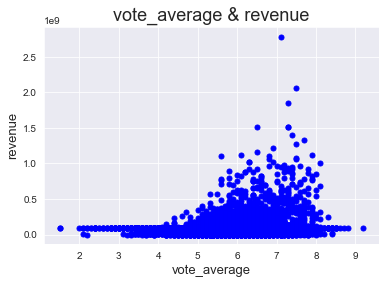

```python
# plotting popularity & Budget
plt.scatter(cleaned_movies['vote_average'], cleaned_movies['revenue'], s= (5*5),
            color='b')
plt.title('vote_average & revenue',fontsize = 18)
plt.xlabel('vote_average',fontsize = 13)
plt.ylabel('revenue',fontsize = 13);
```

**we could see from the scatter a bove that there are movies with highest vote average which had very little revenue .** *the pattern is more obvious compared to the popularity .* **generally higher vote average does indicate a higher possibility of having more revenue generated .**

```python
#  see the most popular director
split_count('director').head()
```

```
Woody Allen         46
Clint Eastwood      34
Martin Scorsese     30
Steven Spielberg    30
Ridley Scott        23
dtype: int64
```

```python
# see the most popular and wanted actors
split_count('cast').head()
```

```
Robert De Niro       72
Samuel L. Jackson    71
Bruce Willis         62
Nicolas Cage         61
Michael Caine        53
dtype: int64
```

```python
# see the most released genres
number_of_genres = split_count('genres')
number_of_genres.head()
```

```
Drama       4743
Comedy      3774
Thriller    2903
Action      2379
Romance     1705
dtype: int64
```

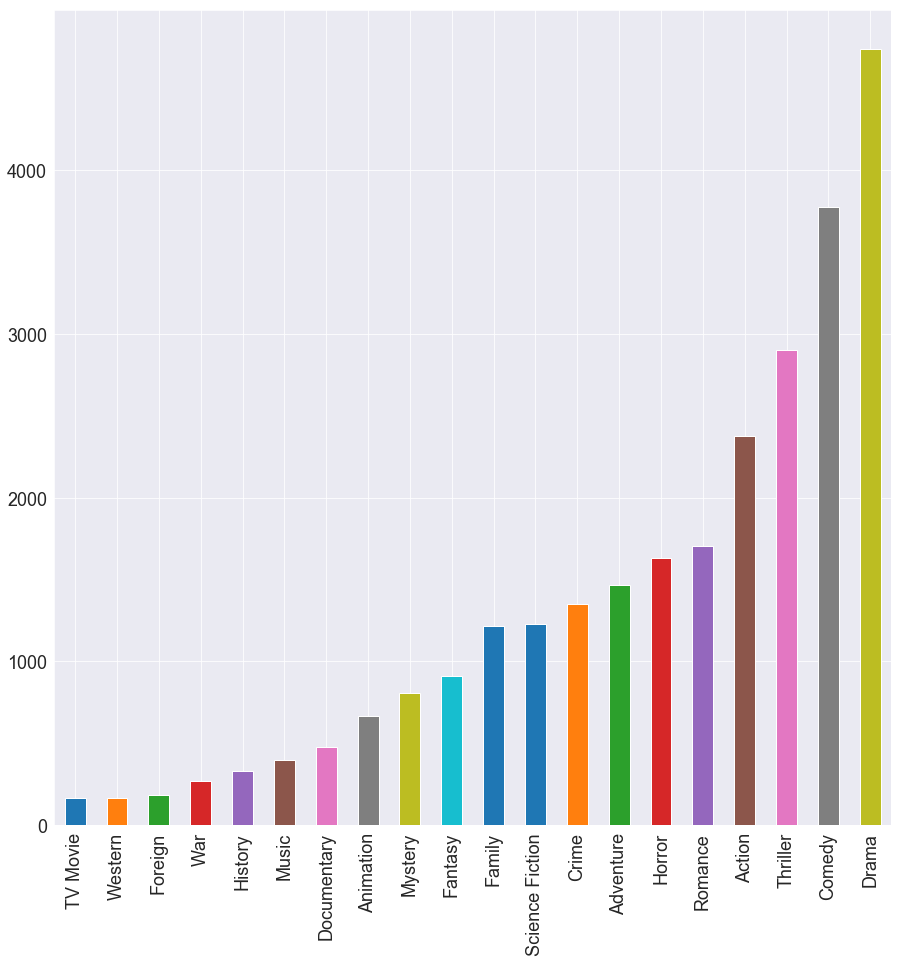

```python
# sort genres
number_of_genres.sort_values(ascending = True, inplace = True)

# plotting
number_of_genres.plot(kind = 'bar',figsize = (15,15),fontsize = 18)

plt.show()
```

### with this bar chart we could see our data and understand it clearly ,which genre is the most released, which type of films do we have

## Conclusions

> **so my conclusion it's that there are important properties that related to the revenue while I could see that when the budget and the popularity are high then the movie will get more Revenue** **neverthless some properties were not connected to the revenue or the budget like the runtime so we can make conclusion that the long movie or the short one doesn't mean that will need more budget or less**

## my resources

- Udacity
- my notebooks
- Udacity reviewesr report for my previous project
- quick google search